# Risk Factor Analysis

## Outcome Variable

**Outcome Variable:** whz

## Predictor Variables

**Intervention Variable:** earlybf

**Adjustment Set:**

- arm
- sex
- W_mage
- meducyrs
- feducyrs
- hhwealth_quart
- hfoodsec
- W_mhtcm
- W_mwtkg
- W_mbmi
- vagbrth
- W_gagebrth
- W_birthwt
- W_birthlen
- W_nrooms
- W_nchldlt5
- brthmon
- W_parity
- impfloor
- impsan
- safeh20
- delta_W_mage
- delta_meducyrs
- delta_feducyrs
- delta_hhwealth_quart
- delta_hfoodsec
- delta_W_mhtcm
- delta_W_mwtkg
- delta_W_mbmi
- delta_vagbrth
- delta_W_gagebrth
- delta_W_birthwt
- delta_W_birthlen
- delta_W_nrooms
- delta_W_nchldlt5
- delta_brthmon
- delta_W_parity
- delta_impfloor
- delta_impsan
- delta_safeh20

## Stratifying Variables

The analysis was stratified on these variable(s):

- agecat
- studyid
- country

## Data Summary

| agecat | studyid | country | earlybf | n_cell | n |
| --- | --- | --- | --- | --- | --- |
| Birth | ki0047075b-MAL-ED | BANGLADESH | 1 | 140 | 214 |
| Birth | ki0047075b-MAL-ED | BANGLADESH | 0 | 74 | 214 |
| Birth | ki0047075b-MAL-ED | BRAZIL | 1 | 26 | 62 |
| Birth | ki0047075b-MAL-ED | BRAZIL | 0 | 36 | 62 |
| Birth | ki0047075b-MAL-ED | INDIA | 1 | 31 | 44 |
| Birth | ki0047075b-MAL-ED | INDIA | 0 | 13 | 44 |
| Birth | ki0047075b-MAL-ED | NEPAL | 1 | 14 | 26 |
| Birth | ki0047075b-MAL-ED | NEPAL | 0 | 12 | 26 |
| Birth | ki0047075b-MAL-ED | PERU | 1 | 172 | 228 |
| Birth | ki0047075b-MAL-ED | PERU | 0 | 56 | 228 |
| Birth | ki0047075b-MAL-ED | SOUTH AFRICA | 1 | 69 | 110 |
| Birth | ki0047075b-MAL-ED | SOUTH AFRICA | 0 | 41 | 110 |
| Birth | ki0047075b-MAL-ED | TANZANIA, UNITED REPUBLIC OF | 1 | 103 | 115 |
| Birth | ki0047075b-MAL-ED | TANZANIA, UNITED REPUBLIC OF | 0 | 12 | 115 |
| Birth | ki1000109-EE | PAKISTAN | 1 | 36 | 170 |
| Birth | ki1000109-EE | PAKISTAN | 0 | 134 | 170 |
| Birth | ki1000304b-SAS-CompFeed | INDIA | 1 | 79 | 1072 |
| Birth | ki1000304b-SAS-CompFeed | INDIA | 0 | 993 | 1072 |
| Birth | ki1017093c-NIH-Crypto | BANGLADESH | 1 | 613 | 707 |
| Birth | ki1017093c-NIH-Crypto | BANGLADESH | 0 | 94 | 707 |
| Birth | ki1113344-GMS-Nepal | NEPAL | 1 | 171 | 586 |
| Birth | ki1113344-GMS-Nepal | NEPAL | 0 | 415 | 586 |
| Birth | ki1126311-ZVITAMBO | ZIMBABWE | 1 | 6142 | 11514 |
| Birth | ki1126311-ZVITAMBO | ZIMBABWE | 0 | 5372 | 11514 |
| Birth | kiGH5241-JiVitA-3 | BANGLADESH | 1 | 124 | 22000 |
| Birth | kiGH5241-JiVitA-3 | BANGLADESH | 0 | 21876 | 22000 |
| Birth | kiGH5241-JiVitA-4 | BANGLADESH | 1 | 1624 | 2396 |
| Birth | kiGH5241-JiVitA-4 | BANGLADESH | 0 | 772 | 2396 |
| 6 months | ki0047075b-MAL-ED | BANGLADESH | 1 | 147 | 240 |
| 6 months | ki0047075b-MAL-ED | BANGLADESH | 0 | 93 | 240 |

[output cut: 52 more lines]

The following strata were considered:

- agecat: 24 months, studyid: ki0047075b-MAL-ED, country: BANGLADESH
- agecat: 24 months, studyid: ki0047075b-MAL-ED, country: BRAZIL
- agecat: 24 months, studyid: ki0047075b-MAL-ED, country: INDIA
- agecat: 24 months, studyid: ki0047075b-MAL-ED, country: NEPAL
- agecat: 24 months, studyid: ki0047075b-MAL-ED, country: PERU
- agecat: 24 months, studyid: ki0047075b-MAL-ED, country: SOUTH AFRICA
- agecat: 24 months, studyid: ki0047075b-MAL-ED, country: TANZANIA, UNITED REPUBLIC OF
- agecat: 24 months, studyid: ki1000109-EE, country: PAKISTAN
- agecat: 24 months, studyid: ki1017093c-NIH-Crypto, country: BANGLADESH
- agecat: 24 months, studyid: ki1113344-GMS-Nepal, country: NEPAL
- agecat: 24 months, studyid: ki1126311-ZVITAMBO, country: ZIMBABWE
- agecat: 24 months, studyid: kiGH5241-JiVitA-3, country: BANGLADESH
- agecat: 24 months, studyid: kiGH5241-JiVitA-4, country: BANGLADESH
- agecat: 6 months, studyid: ki0047075b-MAL-ED, country: BANGLADESH
- agecat: 6 months, studyid: ki0047075b-MAL-ED, country: BRAZIL
- agecat: 6 months, studyid: ki0047075b-MAL-ED, country: INDIA
- agecat: 6 months, studyid: ki0047075b-MAL-ED, country: NEPAL
- agecat: 6 months, studyid: ki0047075b-MAL-ED, country: PERU
- agecat: 6 months, studyid: ki0047075b-MAL-ED, country: SOUTH AFRICA
- agecat: 6 months, studyid: ki0047075b-MAL-ED, country: TANZANIA, UNITED REPUBLIC OF
- agecat: 6 months, studyid: ki1000109-EE, country: PAKISTAN
- agecat: 6 months, studyid: ki1000304b-SAS-CompFeed, country: INDIA
- agecat: 6 months, studyid: ki1017093c-NIH-Crypto, country: BANGLADESH
- agecat: 6 months, studyid: ki1113344-GMS-Nepal, country: NEPAL
- agecat: 6 months, studyid: ki1126311-ZVITAMBO, country: ZIMBABWE
- agecat: 6 months, studyid: kiGH5241-JiVitA-3, country: BANGLADESH
- agecat: 6 months, studyid: kiGH5241-JiVitA-4, country: BANGLADESH
- agecat: Birth, studyid: ki0047075b-MAL-ED, country: BANGLADESH
- agecat: Birth, studyid: ki0047075b-MAL-ED, country: BRAZIL
- agecat: Birth, studyid: ki0047075b-MAL-ED, country: INDIA
- agecat: Birth, studyid: ki0047075b-MAL-ED, country: NEPAL
- agecat: Birth, studyid: ki0047075b-MAL-ED, country: PERU
- agecat: Birth, studyid: ki0047075b-MAL-ED, country: SOUTH AFRICA
- agecat: Birth, studyid: ki0047075b-MAL-ED, country: TANZANIA, UNITED REPUBLIC OF
- agecat: Birth, studyid: ki1000109-EE, country: PAKISTAN
- agecat: Birth, studyid: ki1000304b-SAS-CompFeed, country: INDIA
- agecat: Birth, studyid: ki1017093c-NIH-Crypto, country: BANGLADESH
- agecat: Birth, studyid: ki1113344-GMS-Nepal, country: NEPAL
- agecat: Birth, studyid: ki1126311-ZVITAMBO, country: ZIMBABWE
- agecat: Birth, studyid: kiGH5241-JiVitA-3, country: BANGLADESH
- agecat: Birth, studyid: kiGH5241-JiVitA-4, country: BANGLADESH

### Dropped Strata

Some strata were dropped due to rare outcomes:

- agecat: 24 months, studyid: kiGH5241-JiVitA-3, country: BANGLADESH

## Methods Detail

We’re interested in the causal parameters $E[Y_a]$ for all values of $a \in \mathcal{A}$. These parameters represent the mean outcome if, possibly contrary to fact, we intervened to set all units to have $A=a$. Under the randomization and positivity assumptions, these are identified by the statistical parameters $\psi_a=E_W[E_{Y|A,W}(Y|A=a,W)]$. In addition, we’re interested in the mean of $Y$, $E[Y]$ under no intervention (the observed mean). We will estimate these parameters by using SuperLearner to fit the relevant likelihood factors – $E_{Y|A,W}(Y|A=a,W)$ and $p(A=a|W)$, and then updating our likelihood fit using a joint TMLE.

For unadjusted analyses ($W=\{\}$), initial likelihoods were estimated using Lrnr_glm to estimate the simple $E(Y|A)$ and Lrnr_mean to estimate $p(A)$. For adjusted analyses, a small library containing Lrnr_glmnet, Lrnr_xgboost, and Lrnr_mean was used.

Having estimated these parameters, we will then use the delta method to estimate relative risks and attributable risks relative to a prespecified baseline level of $A$.

# Results Detail

## Results Plots

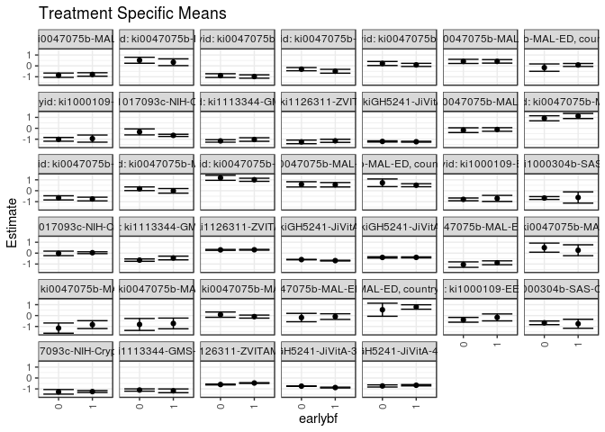

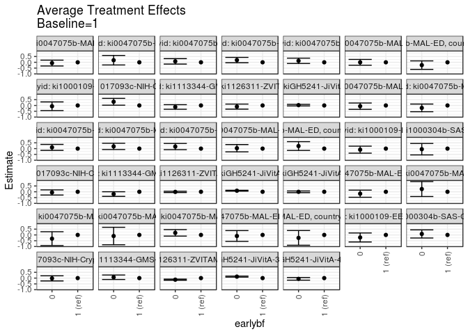

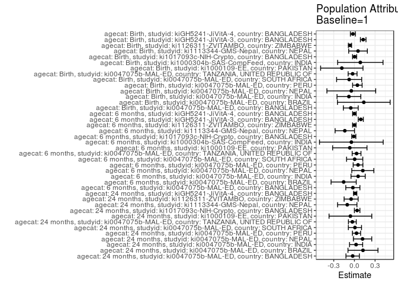

## Results Table

### Parameter: TSM

| agecat | studyid | country | intervention_level | baseline_level | estimate | ci_lower | ci_upper |
| --- | --- | --- | --- | --- | --- | --- | --- |
| Birth | ki0047075b-MAL-ED | BANGLADESH | 1 | NA | -0.8854205 | -1.0642534 | -0.7065877 |
| Birth | ki0047075b-MAL-ED | BANGLADESH | 0 | NA | -1.0499032 | -1.3005199 | -0.7992865 |
| Birth | ki0047075b-MAL-ED | BRAZIL | 1 | NA | 0.2667149 | -0.2328160 | 0.7662458 |
| Birth | ki0047075b-MAL-ED | BRAZIL | 0 | NA | 0.5038465 | 0.0852037 | 0.9224893 |
| Birth | ki0047075b-MAL-ED | INDIA | 1 | NA | -0.8323592 | -1.1928139 | -0.4719046 |
| Birth | ki0047075b-MAL-ED | INDIA | 0 | NA | -1.1533203 | -1.6224937 | -0.6841469 |
| Birth | ki0047075b-MAL-ED | NEPAL | 1 | NA | -0.7232794 | -1.2144981 | -0.2320607 |
| Birth | ki0047075b-MAL-ED | NEPAL | 0 | NA | -0.8162848 | -1.3629708 | -0.2695989 |
| Birth | ki0047075b-MAL-ED | PERU | 1 | NA | -0.0949199 | -0.2339599 | 0.0441201 |
| Birth | ki0047075b-MAL-ED | PERU | 0 | NA | 0.0849708 | -0.1571884 | 0.3271299 |
| Birth | ki0047075b-MAL-ED | SOUTH AFRICA | 1 | NA | -0.0927270 | -0.3518271 | 0.1663731 |
| Birth | ki0047075b-MAL-ED | SOUTH AFRICA | 0 | NA | -0.1835551 | -0.5682482 | 0.2011380 |
| Birth | ki0047075b-MAL-ED | TANZANIA, UNITED REPUBLIC OF | 1 | NA | 0.7889575 | 0.5852763 | 0.9926387 |
| Birth | ki0047075b-MAL-ED | TANZANIA, UNITED REPUBLIC OF | 0 | NA | 0.5344277 | -0.0639874 | 1.1328428 |
| Birth | ki1000109-EE | PAKISTAN | 1 | NA | -0.1692899 | -0.4881659 | 0.1495861 |
| Birth | ki1000109-EE | PAKISTAN | 0 | NA | -0.3885190 | -0.6080741 | -0.1689639 |
| Birth | ki1000304b-SAS-CompFeed | INDIA | 1 | NA | -0.7532932 | -1.1673721 | -0.3392143 |
| Birth | ki1000304b-SAS-CompFeed | INDIA | 0 | NA | -0.6662818 | -0.8340476 | -0.4985160 |
| Birth | ki1017093c-NIH-Crypto | BANGLADESH | 1 | NA | -1.2469515 | -1.3365930 | -1.1573099 |
| Birth | ki1017093c-NIH-Crypto | BANGLADESH | 0 | NA | -1.2702971 | -1.4779012 | -1.0626931 |
| Birth | ki1113344-GMS-Nepal | NEPAL | 1 | NA | -1.1784225 | -1.3495772 | -1.0072678 |
| Birth | ki1113344-GMS-Nepal | NEPAL | 0 | NA | -1.1046364 | -1.2082045 | -1.0010682 |
| Birth | ki1126311-ZVITAMBO | ZIMBABWE | 1 | NA | -0.4617588 | -0.4969740 | -0.4265437 |
| Birth | ki1126311-ZVITAMBO | ZIMBABWE | 0 | NA | -0.5975215 | -0.6355505 | -0.5594926 |
| Birth | kiGH5241-JiVitA-3 | BANGLADESH | 1 | NA | -0.8774797 | -0.9158636 | -0.8390958 |
| Birth | kiGH5241-JiVitA-3 | BANGLADESH | 0 | NA | -0.7492814 | -0.7675114 | -0.7310513 |
| Birth | kiGH5241-JiVitA-4 | BANGLADESH | 1 | NA | -0.6663364 | -0.7258109 | -0.6068619 |
| Birth | kiGH5241-JiVitA-4 | BANGLADESH | 0 | NA | -0.7312283 | -0.8295389 | -0.6329177 |
| 6 months | ki0047075b-MAL-ED | BANGLADESH | 1 | NA | -0.1095065 | -0.2728761 | 0.0538632 |
| 6 months | ki0047075b-MAL-ED | BANGLADESH | 0 | NA | -0.1718708 | -0.3896984 | 0.0459569 |
| 6 months | ki0047075b-MAL-ED | BRAZIL | 1 | NA | 1.1280680 | 0.8934575 | 1.3626784 |
| 6 months | ki0047075b-MAL-ED | BRAZIL | 0 | NA | 0.9186139 | 0.6884349 | 1.1487930 |
| 6 months | ki0047075b-MAL-ED | INDIA | 1 | NA | -0.7620183 | -0.9314682 | -0.5925685 |
| 6 months | ki0047075b-MAL-ED | INDIA | 0 | NA | -0.6550341 | -0.8451928 | -0.4648754 |
| 6 months | ki0047075b-MAL-ED | NEPAL | 1 | NA | -0.0107403 | -0.2219826 | 0.2005020 |
| 6 months | ki0047075b-MAL-ED | NEPAL | 0 | NA | 0.1806233 | 0.0134163 | 0.3478303 |
| 6 months | ki0047075b-MAL-ED | PERU | 1 | NA | 1.0043705 | 0.8607485 | 1.1479925 |
| 6 months | ki0047075b-MAL-ED | PERU | 0 | NA | 1.1814120 | 0.9537256 | 1.4090984 |
| 6 months | ki0047075b-MAL-ED | SOUTH AFRICA | 1 | NA | 0.5467784 | 0.3453015 | 0.7482554 |
| 6 months | ki0047075b-MAL-ED | SOUTH AFRICA | 0 | NA | 0.5828455 | 0.3414381 | 0.8242529 |
| 6 months | ki0047075b-MAL-ED | TANZANIA, UNITED REPUBLIC OF | 1 | NA | 0.5049764 | 0.3635255 | 0.6464273 |
| 6 months | ki0047075b-MAL-ED | TANZANIA, UNITED REPUBLIC OF | 0 | NA | 0.7272806 | 0.3767234 | 1.0778378 |
| 6 months | ki1000109-EE | PAKISTAN | 1 | NA | -0.7055706 | -0.9813297 | -0.4298116 |
| 6 months | ki1000109-EE | PAKISTAN | 0 | NA | -0.7945074 | -0.9209594 | -0.6680554 |
| 6 months | ki1000304b-SAS-CompFeed | INDIA | 1 | NA | -0.6213626 | -1.1358836 | -0.1068417 |
| 6 months | ki1000304b-SAS-CompFeed | INDIA | 0 | NA | -0.6709391 | -0.8034378 | -0.5384405 |
| 6 months | ki1017093c-NIH-Crypto | BANGLADESH | 1 | NA | 0.0388715 | -0.0465411 | 0.1242841 |
| 6 months | ki1017093c-NIH-Crypto | BANGLADESH | 0 | NA | -0.0203348 | -0.2264447 | 0.1857750 |
| 6 months | ki1113344-GMS-Nepal | NEPAL | 1 | NA | -0.4448661 | -0.6157835 | -0.2739487 |
| 6 months | ki1113344-GMS-Nepal | NEPAL | 0 | NA | -0.6412593 | -0.7480048 | -0.5345139 |
| 6 months | ki1126311-ZVITAMBO | ZIMBABWE | 1 | NA | 0.3086371 | 0.2719233 | 0.3453510 |
| 6 months | ki1126311-ZVITAMBO | ZIMBABWE | 0 | NA | 0.2994752 | 0.2586116 | 0.3403389 |
| 6 months | kiGH5241-JiVitA-3 | BANGLADESH | 1 | NA | -0.6855061 | -0.7170185 | -0.6539937 |
| 6 months | kiGH5241-JiVitA-3 | BANGLADESH | 0 | NA | -0.5928388 | -0.6129060 | -0.5727716 |
| 6 months | kiGH5241-JiVitA-4 | BANGLADESH | 1 | NA | -0.3895919 | -0.4340190 | -0.3451647 |
| 6 months | kiGH5241-JiVitA-4 | BANGLADESH | 0 | NA | -0.3926661 | -0.4540070 | -0.3313252 |
| 24 months | ki0047075b-MAL-ED | BANGLADESH | 1 | NA | -0.7894703 | -0.9473710 | -0.6315696 |
| 24 months | ki0047075b-MAL-ED | BANGLADESH | 0 | NA | -0.8556129 | -1.0539899 | -0.6572360 |
| 24 months | ki0047075b-MAL-ED | BRAZIL | 1 | NA | 0.3349544 | 0.0257887 | 0.6441202 |
| 24 months | ki0047075b-MAL-ED | BRAZIL | 0 | NA | 0.5151491 | 0.2420178 | 0.7882804 |
| 24 months | ki0047075b-MAL-ED | INDIA | 1 | NA | -0.9768200 | -1.1331465 | -0.8204935 |
| 24 months | ki0047075b-MAL-ED | INDIA | 0 | NA | -0.8945198 | -1.0674245 | -0.7216150 |
| 24 months | ki0047075b-MAL-ED | NEPAL | 1 | NA | -0.4945072 | -0.6713226 | -0.3176919 |
| 24 months | ki0047075b-MAL-ED | NEPAL | 0 | NA | -0.3019887 | -0.4478512 | -0.1561262 |
| 24 months | ki0047075b-MAL-ED | PERU | 1 | NA | 0.0900087 | -0.0548204 | 0.2348378 |
| 24 months | ki0047075b-MAL-ED | PERU | 0 | NA | 0.2186442 | 0.0325707 | 0.4047177 |
| 24 months | ki0047075b-MAL-ED | SOUTH AFRICA | 1 | NA | 0.4135056 | 0.2529722 | 0.5740389 |
| 24 months | ki0047075b-MAL-ED | SOUTH AFRICA | 0 | NA | 0.4119308 | 0.2225429 | 0.6013188 |
| 24 months | ki0047075b-MAL-ED | TANZANIA, UNITED REPUBLIC OF | 1 | NA | 0.0840335 | -0.0510928 | 0.2191599 |
| 24 months | ki0047075b-MAL-ED | TANZANIA, UNITED REPUBLIC OF | 0 | NA | -0.1594009 | -0.4989712 | 0.1801693 |
| 24 months | ki1000109-EE | PAKISTAN | 1 | NA | -0.9463445 | -1.2742031 | -0.6184858 |
| 24 months | ki1000109-EE | PAKISTAN | 0 | NA | -1.0134267 | -1.1856632 | -0.8411903 |
| 24 months | ki1017093c-NIH-Crypto | BANGLADESH | 1 | NA | -0.6500522 | -0.7505473 | -0.5495572 |
| 24 months | ki1017093c-NIH-Crypto | BANGLADESH | 0 | NA | -0.3323703 | -0.6087137 | -0.0560269 |
| 24 months | ki1113344-GMS-Nepal | NEPAL | 1 | NA | -1.0298304 | -1.1928419 | -0.8668189 |
| 24 months | ki1113344-GMS-Nepal | NEPAL | 0 | NA | -1.1601202 | -1.2723397 | -1.0479007 |
| 24 months | ki1126311-ZVITAMBO | ZIMBABWE | 1 | NA | -1.1491784 | -1.2927168 | -1.0056399 |
| 24 months | ki1126311-ZVITAMBO | ZIMBABWE | 0 | NA | -1.2490787 | -1.4139911 | -1.0841663 |
| 24 months | kiGH5241-JiVitA-4 | BANGLADESH | 1 | NA | -1.2339826 | -1.2740850 | -1.1938802 |
| 24 months | kiGH5241-JiVitA-4 | BANGLADESH | 0 | NA | -1.2058105 | -1.2601165 | -1.1515044 |

### Parameter: E(Y)

| agecat | studyid | country | intervention_level | baseline_level | estimate | ci_lower | ci_upper |
| --- | --- | --- | --- | --- | --- | --- | --- |
| Birth | ki0047075b-MAL-ED | BANGLADESH | NA | NA | -0.9384112 | -1.0842088 | -0.7926136 |
| Birth | ki0047075b-MAL-ED | BRAZIL | NA | NA | 0.4029032 | 0.0896793 | 0.7161272 |
| Birth | ki0047075b-MAL-ED | INDIA | NA | NA | -0.9122727 | -1.1899971 | -0.6345483 |
| Birth | ki0047075b-MAL-ED | NEPAL | NA | NA | -0.7684615 | -1.1257770 | -0.4111460 |
| Birth | ki0047075b-MAL-ED | PERU | NA | NA | -0.0520175 | -0.1725298 | 0.0684947 |
| Birth | ki0047075b-MAL-ED | SOUTH AFRICA | NA | NA | -0.1690000 | -0.3880340 | 0.0500340 |
| Birth | ki0047075b-MAL-ED | TANZANIA, UNITED REPUBLIC OF | NA | NA | 0.7624348 | 0.5710709 | 0.9537986 |
| Birth | ki1000109-EE | PAKISTAN | NA | NA | -0.3522059 | -0.5428560 | -0.1615557 |
| Birth | ki1000304b-SAS-CompFeed | INDIA | NA | NA | -0.6676026 | -0.8422097 | -0.4929956 |
| Birth | ki1017093c-NIH-Crypto | BANGLADESH | NA | NA | -1.2441513 | -1.3281130 | -1.1601897 |
| Birth | ki1113344-GMS-Nepal | NEPAL | NA | NA | -1.1260580 | -1.2184297 | -1.0336863 |
| Birth | ki1126311-ZVITAMBO | ZIMBABWE | NA | NA | -0.5262098 | -0.5537283 | -0.4986913 |
| Birth | kiGH5241-JiVitA-3 | BANGLADESH | NA | NA | -0.7500405 | -0.7678845 | -0.7321964 |
| Birth | kiGH5241-JiVitA-4 | BANGLADESH | NA | NA | -0.6886269 | -0.7410452 | -0.6362086 |
| 6 months | ki0047075b-MAL-ED | BANGLADESH | NA | NA | -0.1323472 | -0.2612119 | -0.0034826 |
| 6 months | ki0047075b-MAL-ED | BRAZIL | NA | NA | 0.9717225 | 0.8073791 | 1.1360658 |
| 6 months | ki0047075b-MAL-ED | INDIA | NA | NA | -0.7082698 | -0.8347304 | -0.5818092 |
| 6 months | ki0047075b-MAL-ED | NEPAL | NA | NA | 0.1110452 | -0.0202712 | 0.2423616 |
| 6 months | ki0047075b-MAL-ED | PERU | NA | NA | 1.0568987 | 0.9352990 | 1.1784983 |
| 6 months | ki0047075b-MAL-ED | SOUTH AFRICA | NA | NA | 0.5505800 | 0.3970988 | 0.7040612 |
| 6 months | ki0047075b-MAL-ED | TANZANIA, UNITED REPUBLIC OF | NA | NA | 0.5362213 | 0.4049390 | 0.6675036 |
| 6 months | ki1000109-EE | PAKISTAN | NA | NA | -0.7725778 | -0.8877440 | -0.6574117 |
| 6 months | ki1000304b-SAS-CompFeed | INDIA | NA | NA | -0.6657084 | -0.8024377 | -0.5289791 |
| 6 months | ki1017093c-NIH-Crypto | BANGLADESH | NA | NA | 0.0297622 | -0.0491685 | 0.1086930 |
| 6 months | ki1113344-GMS-Nepal | NEPAL | NA | NA | -0.5843738 | -0.6761994 | -0.4925481 |
| 6 months | ki1126311-ZVITAMBO | ZIMBABWE | NA | NA | 0.3072633 | 0.2799882 | 0.3345385 |
| 6 months | kiGH5241-JiVitA-3 | BANGLADESH | NA | NA | -0.5930207 | -0.6125866 | -0.5734549 |
| 6 months | kiGH5241-JiVitA-4 | BANGLADESH | NA | NA | -0.3898055 | -0.4270507 | -0.3525603 |
| 24 months | ki0047075b-MAL-ED | BANGLADESH | NA | NA | -0.8150711 | -0.9374454 | -0.6926967 |
| 24 months | ki0047075b-MAL-ED | BRAZIL | NA | NA | 0.4592308 | 0.2528453 | 0.6656163 |
| 24 months | ki0047075b-MAL-ED | INDIA | NA | NA | -0.9522907 | -1.0676596 | -0.8369219 |
| 24 months | ki0047075b-MAL-ED | NEPAL | NA | NA | -0.3764474 | -0.4898516 | -0.2630431 |
| 24 months | ki0047075b-MAL-ED | PERU | NA | NA | 0.1204478 | 0.0005049 | 0.2403906 |
| 24 months | ki0047075b-MAL-ED | SOUTH AFRICA | NA | NA | 0.4211915 | 0.2990776 | 0.5433054 |
| 24 months | ki0047075b-MAL-ED | TANZANIA, UNITED REPUBLIC OF | NA | NA | 0.0539486 | -0.0712465 | 0.1791437 |
| 24 months | ki1000109-EE | PAKISTAN | NA | NA | -1.0044512 | -1.1543739 | -0.8545285 |
| 24 months | ki1017093c-NIH-Crypto | BANGLADESH | NA | NA | -0.6103502 | -0.7050157 | -0.5156847 |
| 24 months | ki1113344-GMS-Nepal | NEPAL | NA | NA | -1.1339602 | -1.2266932 | -1.0412272 |
| 24 months | ki1126311-ZVITAMBO | ZIMBABWE | NA | NA | -1.1970712 | -1.3045749 | -1.0895676 |
| 24 months | kiGH5241-JiVitA-4 | BANGLADESH | NA | NA | -1.2231088 | -1.2549632 | -1.1912543 |

### Parameter: ATE

| agecat | studyid | country | intervention_level | baseline_level | estimate | ci_lower | ci_upper |
| --- | --- | --- | --- | --- | --- | --- | --- |
| Birth | ki0047075b-MAL-ED | BANGLADESH | 1 | 1 | 0.0000000 | 0.0000000 | 0.0000000 |
| Birth | ki0047075b-MAL-ED | BANGLADESH | 0 | 1 | -0.1644826 | -0.4728030 | 0.1438378 |
| Birth | ki0047075b-MAL-ED | BRAZIL | 1 | 1 | 0.0000000 | 0.0000000 | 0.0000000 |
| Birth | ki0047075b-MAL-ED | BRAZIL | 0 | 1 | 0.2371315 | -0.4091052 | 0.8833683 |
| Birth | ki0047075b-MAL-ED | INDIA | 1 | 1 | 0.0000000 | 0.0000000 | 0.0000000 |
| Birth | ki0047075b-MAL-ED | INDIA | 0 | 1 | -0.3209611 | -0.9182994 | 0.2763772 |
| Birth | ki0047075b-MAL-ED | NEPAL | 1 | 1 | 0.0000000 | 0.0000000 | 0.0000000 |
| Birth | ki0047075b-MAL-ED | NEPAL | 0 | 1 | -0.0930054 | -0.8467933 | 0.6607824 |
| Birth | ki0047075b-MAL-ED | PERU | 1 | 1 | 0.0000000 | 0.0000000 | 0.0000000 |
| Birth | ki0047075b-MAL-ED | PERU | 0 | 1 | 0.1798907 | -0.0997279 | 0.4595092 |
| Birth | ki0047075b-MAL-ED | SOUTH AFRICA | 1 | 1 | 0.0000000 | 0.0000000 | 0.0000000 |
| Birth | ki0047075b-MAL-ED | SOUTH AFRICA | 0 | 1 | -0.0908281 | -0.5572761 | 0.3756199 |
| Birth | ki0047075b-MAL-ED | TANZANIA, UNITED REPUBLIC OF | 1 | 1 | 0.0000000 | 0.0000000 | 0.0000000 |
| Birth | ki0047075b-MAL-ED | TANZANIA, UNITED REPUBLIC OF | 0 | 1 | -0.2545298 | -0.8901186 | 0.3810589 |
| Birth | ki1000109-EE | PAKISTAN | 1 | 1 | 0.0000000 | 0.0000000 | 0.0000000 |
| Birth | ki1000109-EE | PAKISTAN | 0 | 1 | -0.2192291 | -0.6059857 | 0.1675275 |
| Birth | ki1000304b-SAS-CompFeed | INDIA | 1 | 1 | 0.0000000 | 0.0000000 | 0.0000000 |
| Birth | ki1000304b-SAS-CompFeed | INDIA | 0 | 1 | 0.0870114 | -0.2644059 | 0.4384287 |
| Birth | ki1017093c-NIH-Crypto | BANGLADESH | 1 | 1 | 0.0000000 | 0.0000000 | 0.0000000 |
| Birth | ki1017093c-NIH-Crypto | BANGLADESH | 0 | 1 | -0.0233456 | -0.2448278 | 0.1981365 |
| Birth | ki1113344-GMS-Nepal | NEPAL | 1 | 1 | 0.0000000 | 0.0000000 | 0.0000000 |
| Birth | ki1113344-GMS-Nepal | NEPAL | 0 | 1 | 0.0737861 | -0.1178189 | 0.2653912 |
| Birth | ki1126311-ZVITAMBO | ZIMBABWE | 1 | 1 | 0.0000000 | 0.0000000 | 0.0000000 |
| Birth | ki1126311-ZVITAMBO | ZIMBABWE | 0 | 1 | -0.1357627 | -0.1836735 | -0.0878519 |
| Birth | kiGH5241-JiVitA-3 | BANGLADESH | 1 | 1 | 0.0000000 | 0.0000000 | 0.0000000 |
| Birth | kiGH5241-JiVitA-3 | BANGLADESH | 0 | 1 | 0.1281984 | 0.0865680 | 0.1698287 |
| Birth | kiGH5241-JiVitA-4 | BANGLADESH | 1 | 1 | 0.0000000 | 0.0000000 | 0.0000000 |
| Birth | kiGH5241-JiVitA-4 | BANGLADESH | 0 | 1 | -0.0648919 | -0.1774819 | 0.0476981 |
| 6 months | ki0047075b-MAL-ED | BANGLADESH | 1 | 1 | 0.0000000 | 0.0000000 | 0.0000000 |
| 6 months | ki0047075b-MAL-ED | BANGLADESH | 0 | 1 | -0.0623643 | -0.3351481 | 0.2104196 |
| 6 months | ki0047075b-MAL-ED | BRAZIL | 1 | 1 | 0.0000000 | 0.0000000 | 0.0000000 |
| 6 months | ki0047075b-MAL-ED | BRAZIL | 0 | 1 | -0.2094540 | -0.5403117 | 0.1214037 |
| 6 months | ki0047075b-MAL-ED | INDIA | 1 | 1 | 0.0000000 | 0.0000000 | 0.0000000 |
| 6 months | ki0047075b-MAL-ED | INDIA | 0 | 1 | 0.1069842 | -0.1485376 | 0.3625060 |
| 6 months | ki0047075b-MAL-ED | NEPAL | 1 | 1 | 0.0000000 | 0.0000000 | 0.0000000 |
| 6 months | ki0047075b-MAL-ED | NEPAL | 0 | 1 | 0.1913636 | -0.0778351 | 0.4605623 |
| 6 months | ki0047075b-MAL-ED | PERU | 1 | 1 | 0.0000000 | 0.0000000 | 0.0000000 |
| 6 months | ki0047075b-MAL-ED | PERU | 0 | 1 | 0.1770415 | -0.0917317 | 0.4458146 |
| 6 months | ki0047075b-MAL-ED | SOUTH AFRICA | 1 | 1 | 0.0000000 | 0.0000000 | 0.0000000 |
| 6 months | ki0047075b-MAL-ED | SOUTH AFRICA | 0 | 1 | 0.0360670 | -0.2788882 | 0.3510223 |
| 6 months | ki0047075b-MAL-ED | TANZANIA, UNITED REPUBLIC OF | 1 | 1 | 0.0000000 | 0.0000000 | 0.0000000 |
| 6 months | ki0047075b-MAL-ED | TANZANIA, UNITED REPUBLIC OF | 0 | 1 | 0.2223042 | -0.1561129 | 0.6007214 |
| 6 months | ki1000109-EE | PAKISTAN | 1 | 1 | 0.0000000 | 0.0000000 | 0.0000000 |
| 6 months | ki1000109-EE | PAKISTAN | 0 | 1 | -0.0889368 | -0.3903894 | 0.2125159 |
| 6 months | ki1000304b-SAS-CompFeed | INDIA | 1 | 1 | 0.0000000 | 0.0000000 | 0.0000000 |
| 6 months | ki1000304b-SAS-CompFeed | INDIA | 0 | 1 | -0.0495765 | -0.5438104 | 0.4446575 |
| 6 months | ki1017093c-NIH-Crypto | BANGLADESH | 1 | 1 | 0.0000000 | 0.0000000 | 0.0000000 |
| 6 months | ki1017093c-NIH-Crypto | BANGLADESH | 0 | 1 | -0.0592063 | -0.2822401 | 0.1638274 |
| 6 months | ki1113344-GMS-Nepal | NEPAL | 1 | 1 | 0.0000000 | 0.0000000 | 0.0000000 |
| 6 months | ki1113344-GMS-Nepal | NEPAL | 0 | 1 | -0.1963932 | -0.3954797 | 0.0026933 |
| 6 months | ki1126311-ZVITAMBO | ZIMBABWE | 1 | 1 | 0.0000000 | 0.0000000 | 0.0000000 |
| 6 months | ki1126311-ZVITAMBO | ZIMBABWE | 0 | 1 | -0.0091619 | -0.0636081 | 0.0452843 |
| 6 months | kiGH5241-JiVitA-3 | BANGLADESH | 1 | 1 | 0.0000000 | 0.0000000 | 0.0000000 |
| 6 months | kiGH5241-JiVitA-3 | BANGLADESH | 0 | 1 | 0.0926673 | 0.0549211 | 0.1304135 |
| 6 months | kiGH5241-JiVitA-4 | BANGLADESH | 1 | 1 | 0.0000000 | 0.0000000 | 0.0000000 |
| 6 months | kiGH5241-JiVitA-4 | BANGLADESH | 0 | 1 | -0.0030742 | -0.0756998 | 0.0695513 |
| 24 months | ki0047075b-MAL-ED | BANGLADESH | 1 | 1 | 0.0000000 | 0.0000000 | 0.0000000 |
| 24 months | ki0047075b-MAL-ED | BANGLADESH | 0 | 1 | -0.0661426 | -0.3186849 | 0.1863997 |
| 24 months | ki0047075b-MAL-ED | BRAZIL | 1 | 1 | 0.0000000 | 0.0000000 | 0.0000000 |
| 24 months | ki0047075b-MAL-ED | BRAZIL | 0 | 1 | 0.1801947 | -0.2299109 | 0.5903002 |
| 24 months | ki0047075b-MAL-ED | INDIA | 1 | 1 | 0.0000000 | 0.0000000 | 0.0000000 |
| 24 months | ki0047075b-MAL-ED | INDIA | 0 | 1 | 0.0823003 | -0.1514141 | 0.3160146 |
| 24 months | ki0047075b-MAL-ED | NEPAL | 1 | 1 | 0.0000000 | 0.0000000 | 0.0000000 |
| 24 months | ki0047075b-MAL-ED | NEPAL | 0 | 1 | 0.1925186 | -0.0358199 | 0.4208571 |
| 24 months | ki0047075b-MAL-ED | PERU | 1 | 1 | 0.0000000 | 0.0000000 | 0.0000000 |
| 24 months | ki0047075b-MAL-ED | PERU | 0 | 1 | 0.1286355 | -0.1010719 | 0.3583429 |
| 24 months | ki0047075b-MAL-ED | SOUTH AFRICA | 1 | 1 | 0.0000000 | 0.0000000 | 0.0000000 |
| 24 months | ki0047075b-MAL-ED | SOUTH AFRICA | 0 | 1 | -0.0015748 | -0.2501109 | 0.2469614 |
| 24 months | ki0047075b-MAL-ED | TANZANIA, UNITED REPUBLIC OF | 1 | 1 | 0.0000000 | 0.0000000 | 0.0000000 |
| 24 months | ki0047075b-MAL-ED | TANZANIA, UNITED REPUBLIC OF | 0 | 1 | -0.2434345 | -0.6087557 | 0.1218867 |
| 24 months | ki1000109-EE | PAKISTAN | 1 | 1 | 0.0000000 | 0.0000000 | 0.0000000 |
| 24 months | ki1000109-EE | PAKISTAN | 0 | 1 | -0.0670823 | -0.4398222 | 0.3056576 |
| 24 months | ki1017093c-NIH-Crypto | BANGLADESH | 1 | 1 | 0.0000000 | 0.0000000 | 0.0000000 |
| 24 months | ki1017093c-NIH-Crypto | BANGLADESH | 0 | 1 | 0.3176819 | 0.0238492 | 0.6115147 |
| 24 months | ki1113344-GMS-Nepal | NEPAL | 1 | 1 | 0.0000000 | 0.0000000 | 0.0000000 |
| 24 months | ki1113344-GMS-Nepal | NEPAL | 0 | 1 | -0.1302898 | -0.3287971 | 0.0682175 |
| 24 months | ki1126311-ZVITAMBO | ZIMBABWE | 1 | 1 | 0.0000000 | 0.0000000 | 0.0000000 |
| 24 months | ki1126311-ZVITAMBO | ZIMBABWE | 0 | 1 | -0.0999004 | -0.3185865 | 0.1187857 |
| 24 months | kiGH5241-JiVitA-4 | BANGLADESH | 1 | 1 | 0.0000000 | 0.0000000 | 0.0000000 |
| 24 months | kiGH5241-JiVitA-4 | BANGLADESH | 0 | 1 | 0.0281722 | -0.0396458 | 0.0959901 |

### Parameter: PAR

| agecat | studyid | country | intervention_level | baseline_level | estimate | ci_lower | ci_upper |
| --- | --- | --- | --- | --- | --- | --- | --- |
| Birth | ki0047075b-MAL-ED | BANGLADESH | 1 | NA | -0.0529907 | -0.1609680 | 0.0549867 |
| Birth | ki0047075b-MAL-ED | BRAZIL | 1 | NA | 0.1361883 | -0.2463612 | 0.5187377 |
| Birth | ki0047075b-MAL-ED | INDIA | 1 | NA | -0.0799135 | -0.2526737 | 0.0928467 |
| Birth | ki0047075b-MAL-ED | NEPAL | 1 | NA | -0.0451821 | -0.3994905 | 0.3091262 |
| Birth | ki0047075b-MAL-ED | PERU | 1 | NA | 0.0429024 | -0.0260824 | 0.1118871 |
| Birth | ki0047075b-MAL-ED | SOUTH AFRICA | 1 | NA | -0.0762730 | -0.2583822 | 0.1058362 |
| Birth | ki0047075b-MAL-ED | TANZANIA, UNITED REPUBLIC OF | 1 | NA | -0.0265227 | -0.0911300 | 0.0380846 |
| Birth | ki1000109-EE | PAKISTAN | 1 | NA | -0.1829160 | -0.4904945 | 0.1246626 |
| Birth | ki1000304b-SAS-CompFeed | INDIA | 1 | NA | 0.0856906 | -0.2439052 | 0.4152864 |
| Birth | ki1017093c-NIH-Crypto | BANGLADESH | 1 | NA | 0.0028001 | -0.0268783 | 0.0324786 |
| Birth | ki1113344-GMS-Nepal | NEPAL | 1 | NA | 0.0523645 | -0.0833101 | 0.1880391 |
| Birth | ki1126311-ZVITAMBO | ZIMBABWE | 1 | NA | -0.0644510 | -0.0879827 | -0.0409193 |
| Birth | kiGH5241-JiVitA-3 | BANGLADESH | 1 | NA | 0.1274393 | 0.0868458 | 0.1680328 |
| Birth | kiGH5241-JiVitA-4 | BANGLADESH | 1 | NA | -0.0222905 | -0.0586162 | 0.0140352 |
| 6 months | ki0047075b-MAL-ED | BANGLADESH | 1 | NA | -0.0228407 | -0.1255213 | 0.0798398 |
| 6 months | ki0047075b-MAL-ED | BRAZIL | 1 | NA | -0.1563455 | -0.3390290 | 0.0263380 |
| 6 months | ki0047075b-MAL-ED | INDIA | 1 | NA | 0.0537486 | -0.0494973 | 0.1569944 |
| 6 months | ki0047075b-MAL-ED | NEPAL | 1 | NA | 0.1217855 | -0.0384215 | 0.2819925 |
| 6 months | ki0047075b-MAL-ED | PERU | 1 | NA | 0.0525281 | -0.0180293 | 0.1230855 |
| 6 months | ki0047075b-MAL-ED | SOUTH AFRICA | 1 | NA | 0.0038016 | -0.1141427 | 0.1217458 |
| 6 months | ki0047075b-MAL-ED | TANZANIA, UNITED REPUBLIC OF | 1 | NA | 0.0312450 | -0.0326652 | 0.0951551 |
| 6 months | ki1000109-EE | PAKISTAN | 1 | NA | -0.0670072 | -0.3164574 | 0.1824430 |
| 6 months | ki1000304b-SAS-CompFeed | INDIA | 1 | NA | -0.0443458 | -0.5067091 | 0.4180176 |
| 6 months | ki1017093c-NIH-Crypto | BANGLADESH | 1 | NA | -0.0091093 | -0.0389068 | 0.0206883 |
| 6 months | ki1113344-GMS-Nepal | NEPAL | 1 | NA | -0.1395077 | -0.2805646 | 0.0015493 |
| 6 months | ki1126311-ZVITAMBO | ZIMBABWE | 1 | NA | -0.0013738 | -0.0267238 | 0.0239762 |
| 6 months | kiGH5241-JiVitA-3 | BANGLADESH | 1 | NA | 0.0924854 | 0.0556792 | 0.1292915 |
| 6 months | kiGH5241-JiVitA-4 | BANGLADESH | 1 | NA | -0.0002136 | -0.0260921 | 0.0256649 |
| 24 months | ki0047075b-MAL-ED | BANGLADESH | 1 | NA | -0.0256008 | -0.1231121 | 0.0719105 |
| 24 months | ki0047075b-MAL-ED | BRAZIL | 1 | NA | 0.1242763 | -0.0935012 | 0.3420538 |
| 24 months | ki0047075b-MAL-ED | INDIA | 1 | NA | 0.0245293 | -0.0710317 | 0.1200903 |
| 24 months | ki0047075b-MAL-ED | NEPAL | 1 | NA | 0.1180599 | -0.0154388 | 0.2515586 |
| 24 months | ki0047075b-MAL-ED | PERU | 1 | NA | 0.0304391 | -0.0288509 | 0.0897291 |
| 24 months | ki0047075b-MAL-ED | SOUTH AFRICA | 1 | NA | 0.0076859 | -0.0879980 | 0.1033698 |
| 24 months | ki0047075b-MAL-ED | TANZANIA, UNITED REPUBLIC OF | 1 | NA | -0.0300849 | -0.0869317 | 0.0267618 |
| 24 months | ki1000109-EE | PAKISTAN | 1 | NA | -0.0581068 | -0.3683770 | 0.2521635 |
| 24 months | ki1017093c-NIH-Crypto | BANGLADESH | 1 | NA | 0.0397020 | -0.0001950 | 0.0795991 |
| 24 months | ki1113344-GMS-Nepal | NEPAL | 1 | NA | -0.1041298 | -0.2447609 | 0.0365012 |
| 24 months | ki1126311-ZVITAMBO | ZIMBABWE | 1 | NA | -0.0478929 | -0.1496224 | 0.0538367 |
| 24 months | kiGH5241-JiVitA-4 | BANGLADESH | 1 | NA | 0.0108739 | -0.0132998 | 0.0350475 |